[figure not shown]

# v2.0

## Molecular Pathology Platform

> Inserm U970, 56 rue Leblanc 75015 Paris, France  
> **Team leader:** Pr Alexandre Loupy MD/PhD  
> **Project managers:** Fariza Mezine & Dina Zielinski PhD  
> **Contact:** jessy.dagobert@inserm.fr / +33-1-53-98-80-85

## Sample info:

| Patient name | Jean Deaux | Donor type | living |
| --- | --- | --- | --- |
| Date of transplantation | 7/7/17 | Initial nephropathy | IgA Nephropathy |
| Date of biopsy | 1/1/18 | Histology | Acute TCMR grade I (Banff: i2 t2 v1 g0, ci1, ct1) |

## Gene expression based probabilities:

| Diagnosis | test | Sample range | Normal range | Interpretation |
| --- | --- | --- | --- | --- |
| AMR | 8.1 | 0 - 9.6 | 0.5 - 6.4 | unlikely |
| TCMR | 75.1 | 68.7 - 84.1 | 0.4 - 7 | high probability |

Diagnosis based scores represent the probability (0-100%) that a biopsy has an expression profile similar to reference samples with a given histology based rejection diagnosis (AMR or TCMR).  
‘Sample range’ is the confidence interval for the predicted probabilities of the tested sample.  
‘Normal range’ is the middle 50% of scores in biopsies with no rejection or injury diagnosis.

## Principal Components Analysis (PCA) of molecular scores:

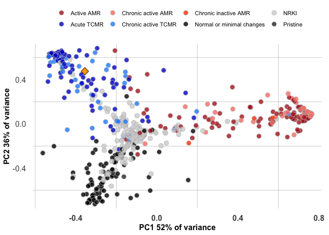

Samples are labeled by histologic diagnosis (NRKI=non-rejection kidney injury). The tested sample is the yellow diamond.

### Histologic Diagnosis of 25 Nearest Neighbors

| Diagnosis | Total | Percent |
| --- | --- | --- |
| Acute TCMR | 13 | 52 |
| Chronic active TCMR | 8 | 32 |
| NRKI | 3 | 12 |
| Normal or minimal changes | 1 | 4 |

### Clinician signout

| Name | Signature |
| --- | --- |
| > |  |

> *Comments:*

## Technical details

### RNA quality

| Platform ID | Center ID | 260/280 ratio | 260/230 ratio | concentration | units | status |
| --- | --- | --- | --- | --- | --- | --- |
| test | test_123 | 1.9 | 2 | 25 | ng/ul | Passed |

“Caution” status indicates a concentration within the minimum recommended 10-20ng/ul range  
“Warning” status indicates a concentration lower than the recommended minimum 10ng/ul

### NanoString run information

| SoftwareVersion | 4.0.0.3 | geo mean NEG genes | 10.28 |
| --- | --- | --- | --- |
| Date | 20210819 | geo mean ENDO genes | 78.44 |
| GeneRLF | NS_Hs_Transplant_v1.0 | POS_E counts | 161.00 |
| BindingDensity | 0.69 | LoD | 19.49 |
| % registered FOVs | 100.00 | % ENDO genes above LoD | 81.00 |
| geo mean POS genes | 1613.88 | PCL | 1.00 |

FoV=fields of view | geo mean=geometric mean | LoD=limit of detection | PCL=positive control linearity

**Recommended QC thresholds:**  
Registered FoVs >75% | PCL >0.95 | Binding Density 0.05-2.25 | 80% ENDO genes >LoD | POS_E counts >LoD

### For research use only:

Models have been not been validated in clinical settings or trials. This report does not replace a standard diagnosis. Due to known technical variation, RNA later-fixed samples should be interpreted with caution.

[figure not shown]

[paristransplantinstitute.org](https://www.paristransplantgroup.org/)